# varycoef: An R Package to Model Spatially Varying Coefficients

Jakob A. Dambon

October 2019, Updated: August 2022

## Introduction

With the release of the R package `varycoef` on CRAN ([see](https://CRAN.R-project.org/package=varycoef)) we enable you to analyze your spatial data and in a simple, yet versatile way. The underlying idea are *spatially varying coefficients* (SVC) that extend the linear model

$$y_i = x_i^{(1)} \beta_1 + ... +
x_i^{(p)} \beta_p + \varepsilon_i$$
by allowing the coefficients $\beta_j, j = 1, ..., p$ to vary over space. In particular, we use so-called *Gaussian processes* (GP) to define the spatial structure of the coefficients. Therefore, our models are called *GP-based SVC models*.

In this article, we will show what SVC models are and how to define them. Afterwards, we give a short and illustrative example with synthetic data and show how to apply the methods provided in `varycoef`. Finally, using the well known data set `meuse` from the package `sp`.

### Disclaimer

Th analyses and results in this article are meant to be a show case of what is possible using the package `varycoef` and **not** to write the most rigorous statistical analysis of a data set. As this article should make the usage of `varycoef` as simple as possible, we skip over some of the technical or mathematical details and in some cases abuse notation. For a rigorous definition, please refer to the resources below. Further, the model estimation is performed on rather small data sets ($n < 200$) to ease computation. We recommend to apply SVC models, particularly with many coefficients, on larger data sets.

### Further References

Our package evolved over time and we present some highlights:

- In [Dambon et al. (2021a)](https://www.sciencedirect.com/science/article/pii/S2211675320300646) we introduce the GP-based SVC model and the methodology on how to estimate them. Further, we provide a comparison on synthetic and real world data with other SVC methodologies.
- In [Dambon et al. (2022a)](https://sjes.springeropen.com/articles/10.1186/s41937-021-00080-2) we present an in-depth analysis of Swiss real estate data using GP-based SVC models.
- In Dambon et al. (2022b) we introduce a variable selection method. This is not covered by this article.

### Preliminaries

Before we start, we want to give some prerequisites that you should know about in order to follow the analysis below. Beside a classical linear regression model, we require the knowledge of:

- spatial data and geostatistics
- Gaussian processes and Gaussian random fields
- covariance functions and how the range and variance parameter influence them
- maximum likelihood estimation

### Set up

The `varycoef` package is available via [CRAN](https://cran.r-project.org/web/packages/varycoef/index.html) or [Github](https://github.com/jakobdambon/varycoef). Latter one hosts the most recent version that is released to CRAN on a regular base.

```r
# install from CRAN
install.packages("varycoef")

# install from Github (make sure that you installed the package "devtools")
devtools::install_github("jakobdambon/varycoef")
```

### Where to find help?

Within the R package, you can use these resources:

```r
# attach package
library(varycoef)

# general package help file
help("varycoef")

# where you find this vignette
vignette("Introduction", package = "varycoef")
```

You can find this article on the Github, too. We continue to add more material and examples in the future.

## Synthetic Data Example

Let’s dive into the analysis of some synthetic data. To ease the visualization, we will work with one-dimensional spatial data, i.e., any location $s$ is from the real line $\mathbb R$. We want to highlight that are package is not restricted to such analysis and that we can analyze spatial data from higher dimensions, i.e., $s \in \mathbb R^d$, where $d \geq 1$.

### Model and Data

As mentioned before, an SVC model extends the linear model by allowing the coefficients to vary over space. Therefore, we can write:

$$y_i = x_i^{(1)} \beta_1(s) + ... +
x_i^{(p)} \beta_p(s) + \varepsilon_i,$$
for some location $s$ where $\beta_1(s)$n indicates the dependence of a coefficient on the space. The coefficients are defined by Gaussian processes, but we skip over this part for now and take a look at a data set that was sampled using the model above. In `varycoef`, a data set named `SVCdata` is provided:

```r
str(SVCdata)
```

```
## List of 6
##  $ y        : num [1:500] -1.488 3.901 0.197 -3.326 2.722 ...
##  $ X        : num [1:500, 1:2] 1 1 1 1 1 1 1 1 1 1 ...
##  $ beta     : num [1:500, 1:2] 0.469 0.468 0.452 0.447 0.445 ...
##  $ eps      : num [1:500] 0.526 0.311 0.217 0.193 0.646 ...
##  $ locs     : num [1:500] 0.00465 0.00625 0.06301 0.08216 0.0943 ...
##  $ true_pars:'data.frame':   2 obs. of  4 variables:
##   ..$ nu   : num [1:2] 1.5 1.5
##   ..$ var  : num [1:2] 2 1
##   ..$ scale: num [1:2] 3 1
##   ..$ mean : num [1:2] 1 2
```

```r
help(SVCdata)
# number of observations, number of coefficients
n <- nrow(SVCdata$X); p <- ncol(SVCdata$X)
```

It consists of the response `y`, the model matrix `X`, the locations `locs`, and the usually unknown true coefficients `beta`, error `eps`, and true parameters `true_pars`. The model matrix is of dimension $500 \times 2$, i.e., we have $500$ observations and $p = 2$ coefficients. The first column of `X` is identical to 1 to model the intercept.

We will use 100 observations of the data to train the model and leave the remaining 400 out as a test sample, i.e.:

```r
# create data frame
df <- with(SVCdata, data.frame(y = y, x = X[, 2], locs = locs))
set.seed(123)
idTrain <- sort(sample(n, n*prop_train))
df_train <- df[idTrain, ]
df_test <- df[-idTrain, ]
```

### Exploratory Data Analysis

We plot the part of the data that is usually available to us:

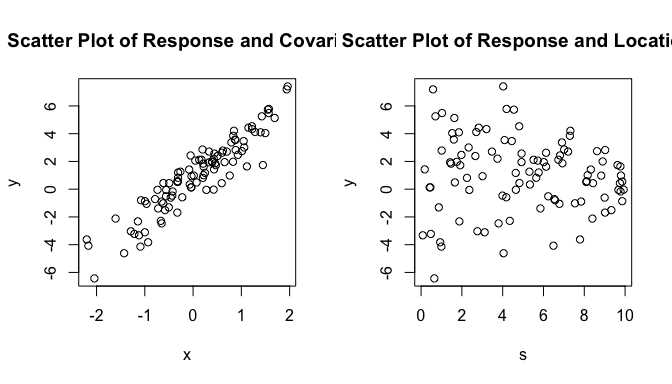

```r
par(mfrow = 1:2)
plot(y ~ x, data = df_train, xlab = "x", ylab = "y",
     main = "Scatter Plot of Response and Covariate")
plot(y ~ locs, data = df_train, xlab = "s", ylab = "y",
     main = "Scatter Plot of Response and Locations")
```

```r
par(mfrow = c(1, 1))
```

We note that there is a clear linear dependency between the covariate and the response. However, there is not a clear spatial structure. We estimate a linear model and analyze the residuals thereof.

```r
fit_lm <- lm(y ~ x, data = df_train)
summary(fit_lm)
```

```
##
## Call:
## lm(formula = y ~ x, data = df_train)
##
## Residuals:
##     Min      1Q  Median      3Q     Max
## -2.9202 -0.5527  0.1712  0.6972  1.7988
##
## Coefficients:
##             Estimate Std. Error t value Pr(>|t|)
## (Intercept)  0.77032    0.09965    7.73  9.5e-12 ***
## x            2.68853    0.10866   24.74  < 2e-16 ***
## ---
## Signif. codes:  0 '***' 0.001 '**' 0.01 '*' 0.05 '.' 0.1 ' ' 1
##
## Residual standard error: 0.9904 on 98 degrees of freedom
## Multiple R-squared:  0.862,  Adjusted R-squared:  0.8606
## F-statistic: 612.2 on 1 and 98 DF,  p-value: < 2.2e-16
```

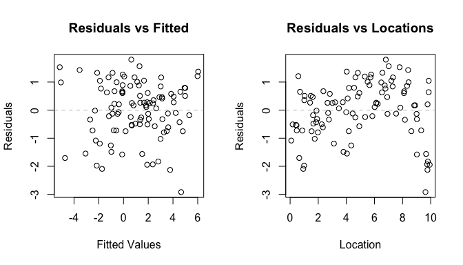

```r
# residual plots
par(mfrow = 1:2)
plot(x = fitted(fit_lm), y = resid(fit_lm),
     xlab = "Fitted Values", ylab = "Residuals",
     main = "Residuals vs Fitted")
abline(h = 0, lty = 2, col = "grey")
plot(x = df_train$locs, y = resid(fit_lm), xlab = "Location", ylab = "Residuals",
     main = "Residuals vs Locations")
abline(h = 0, lty = 2, col = "grey")
```

```r
par(mfrow = c(1, 1))
```

Discarding the spatial information, we observe no structure within the residuals (Figure above, LHS). However, if we plot the residuals against there location, we clearly see some spatial structure. Therefore, we will apply the SVC model next.

### SVC Model

To estimate an SVC model, we can use the `SVC_mle()` function almost like the `lm()` function from above. As the name suggests, we use a *maximum likelihood estimation* (MLE) for estimating the parameters. We ignore the covariance parameters in the `summary()`-output for the moment.

```r
fit_svc <- SVC_mle(y ~ x, data = df_train, locs = df_train$locs)
summary(fit_svc)
```

```
##
## Call:
## SVC_mle.formula(formula = y ~ x, data = df_train, locs = df_train$locs)
##
## Fitting a GP-based SVC model with 2 fixed effect(s) and 2 SVC(s)
## using 100 observations at 100 different locations / coordinates.
##
## Residuals:
##     Min.   1st Qu.    Median   3rd Qu.      Max.
## -1.25497  -0.26972   0.01098   0.30372   0.98823
##
## Residual standard error: 0.4307
## Multiple R-squared: 0.9736, BIC: 231.8
##
##
## Coefficients of fixed effect(s):
##             Estimate Std. Error Z value Pr(>|Z|)
## (Intercept)   0.6491     0.2838   2.287   0.0222 *
## x             2.5468     0.3499   7.280 3.35e-13 ***
## ---
## Signif. codes:  0 '***' 0.001 '**' 0.01 '*' 0.05 '.' 0.1 ' ' 1
##
##
## Covariance parameters of the SVC(s):
##                   Estimate Std. Error W value Pr(>W)
## (Intercept).range  1.68358    1.44902      NA     NA
## (Intercept).var    0.25786    0.15979   2.604 0.1066
## x.range            1.31196    1.16981      NA     NA
## x.var              0.51061    0.31030   2.708 0.0999 .
## nugget.var         0.26822    0.05479      NA     NA
## ---
## Signif. codes:  0 '***' 0.001 '**' 0.01 '*' 0.05 '.' 0.1 ' ' 1
##
## The covariance parameters were estimated using
## exponential covariance functions.
## No covariance tapering applied.
##
##
## MLE:
## The MLE terminated after 76 function evaluations with convergence code 0
## (0 meaning that the optimization was succesful).
## The final log likelihood value is -106.7.
```

The only additional argument that we have to provide explicitly are the observation locations. The output is an object of class SVC_mle. We can apply most of the methods that exist for `lm` objects to out output, too. For instance methods of `summary()`, `fitted()`, or `resid()`:

```r
summary(fit_svc)
```

```
##
## Call:
## SVC_mle.formula(formula = y ~ x, data = df_train, locs = df_train$locs)
##
## Fitting a GP-based SVC model with 2 fixed effect(s) and 2 SVC(s)
## using 100 observations at 100 different locations / coordinates.
##
## Residuals:
##     Min.   1st Qu.    Median   3rd Qu.      Max.
## -1.25497  -0.26972   0.01098   0.30372   0.98823
##
## Residual standard error: 0.4307
## Multiple R-squared: 0.9736, BIC: 231.8
##
##
## Coefficients of fixed effect(s):
##             Estimate Std. Error Z value Pr(>|Z|)
## (Intercept)   0.6491     0.2838   2.287   0.0222 *
## x             2.5468     0.3499   7.280 3.35e-13 ***
## ---
## Signif. codes:  0 '***' 0.001 '**' 0.01 '*' 0.05 '.' 0.1 ' ' 1
##
##
## Covariance parameters of the SVC(s):
##                   Estimate Std. Error W value Pr(>W)
## (Intercept).range  1.68358    1.44902      NA     NA
## (Intercept).var    0.25786    0.15979   2.604 0.1066
## x.range            1.31196    1.16981      NA     NA
## x.var              0.51061    0.31030   2.708 0.0999 .
## nugget.var         0.26822    0.05479      NA     NA
## ---
## Signif. codes:  0 '***' 0.001 '**' 0.01 '*' 0.05 '.' 0.1 ' ' 1
##
## The covariance parameters were estimated using
## exponential covariance functions.
## No covariance tapering applied.
##
##
## MLE:
## The MLE terminated after 76 function evaluations with convergence code 0
## (0 meaning that the optimization was succesful).
## The final log likelihood value is -106.7.
```

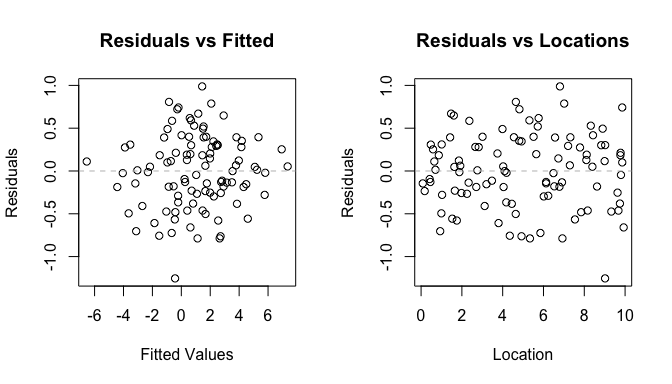

```r
# residual plots
par(mfrow = 1:2)
plot(x = fitted(fit_svc)$y.pred, y = resid(fit_svc),
     xlab = "Fitted Values", ylab = "Residuals",
     main = "Residuals vs Fitted")
abline(h = 0, lty = 2, col = "grey")
plot(x = df_train$locs, y = resid(fit_svc), xlab = "Location", ylab = "Residuals",
     main = "Residuals vs Locations")
abline(h = 0, lty = 2, col = "grey")
```

```r
par(mfrow = c(1, 1))
```

Compared to the output and residuals of the linear models, we immediately see that the residuals of the SVC model are smaller in range and do not have a spatial structure. They are both with respect to fitted values and locations distributed around 0 and homoscedastic.

### Comparison of Models

We end this example on a synthetic data set by comparing the linear with the SVC model. We already saw some advantages of the SVC model when investigating the residuals. Now, we take a look at the quality of the model fit, the model interpretation, and the predictive performance.

#### Model Fit

We can compare the models by the log likelihood, Akaike’s or the Bayesian information criterion (AIC and BIC, respectively):

[output not shown]

#### Model Interpretation

While the linear model estimates constant coefficients, contrary and as the name suggests, the SVC model’s coefficients vary over space. That is why the `fitted()` method does not only return the fitted response, but also the fitted coefficients and at their given locations:

|  | SVC_1 | SVC_2 | y.pred | loc_1 |
| --- | --- | --- | --- | --- |
| 4 | -0.3353062 | 0.5712240 | -3.1805285 | 0.0821552 |
| 7 | -0.3390177 | 0.5691786 | 1.6638651 | 0.1776581 |
| 13 | -0.2881019 | 0.6498610 | 0.2224001 | 0.4205953 |
| 14 | -0.2775242 | 0.6628253 | 0.2605299 | 0.4555650 |
| 16 | -0.2681113 | 0.6705916 | -3.5324973 | 0.4766363 |
| 23 | -0.2584885 | 0.8309101 | 6.9425422 | 0.5847849 |

We visualize the coefficients at their respective locations. **One important thing to note is that the fitted values are the deviations from the mean value**. Therefore, we need to add the mean to the fitte deviations:

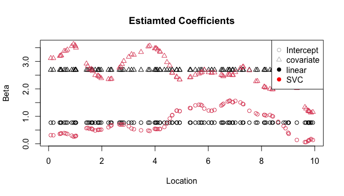

```r
mat_coef <- cbind(
  lin1 = coef(fit_lm)[1], lin2 = coef(fit_lm)[2],
  svc1 = coef(fit_svc)[1] + fitted(fit_svc)[, 1],
  svc2 = coef(fit_svc)[2] + fitted(fit_svc)[, 2]
)
matplot(
  x = df_train$locs,
  y = mat_coef, pch = c(1, 2, 1, 2), col = c(1, 1, 2, 2),
  xlab = "Location", ylab = "Beta", main = "Estiamted Coefficients")
legend("topright", legend = c("Intercept", "covariate", "linear", "SVC"),
       pch = c(1, 2, 19, 19), col = c("grey", "grey", "black", "red"))
```

The interpretation of both models is quite similar. Whereas the linear model estimates constant coefficients that hold for the entire domain, the SVC model estimates coefficients’ means and some respective deviation. The SVC model interpretation in a nutshell: **Given a location, the SVC model behaves like a linear model.**

#### Predictve Performance

We use the entire data set to compute the in- and out-of-sample rooted mean square error (RMSE) for the response for both the linear and SVC model. Here we rely on the `predict()` methods. Further, we can compare the predicted coefficients with the true coefficients provided in `SVCdata`, something that we usually cannot do.

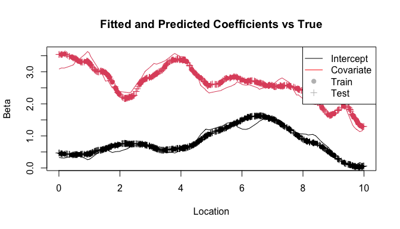

```r
df_svc_pred <- predict(fit_svc, newdata = df, newlocs = df$locs)
mat_coef_pred <- cbind(
  svc1_pred = coef(fit_svc)[1] + df_svc_pred[, 1],
  svc2_pred = coef(fit_svc)[2] + df_svc_pred[, 2]
)
matplot(x = df$locs, y = mat_coef_pred,
        xlab = "Location", ylab = "Beta",
        main = "Fitted and Predicted Coefficients vs True",
        col = c(1, 2), lty = c(1, 1), type = "l")
pch <- rep(19, n); pch[-idTrain] <- 3
points(x = df$locs, y = SVCdata$beta[, 1], col = 1, pch = pch)
points(x = df$locs, y = SVCdata$beta[, 2], col = 2, pch = pch)
legend("topright", legend = c("Intercept", "Covariate", "Train", "Test"),
       col = c("black", "red", "grey", "grey"),
       pch = c(NA, NA, 19, 3),
       lty = c(1, 1, NA, NA))
```

Let us compute the errors:

```r
SE_lm <- (predict(fit_lm, newdata = df) - df$y)^2
# df_svc_pred from above
SE_svc <- (df_svc_pred$y.pred - df$y)^2
kable(data.frame(
  model = c("linear", "SVC"),
  `in-sample RMSE` = sqrt(c(mean(SE_lm[idTrain]), mean(SE_svc[idTrain]))),
  `out-of-sample RMSE` = sqrt(c(mean(SE_lm[-idTrain]), mean(SE_svc[-idTrain])))
))
```

| model | in.sample.RMSE | out.of.sample.RMSE |
| --- | --- | --- |
| linear | 0.9804827 | 0.7911859 |
| SVC | 0.4285585 | 0.5578723 |

We notice a significant difference in both the in- and out-of-sample RMSE.

## Meuse Data Set Example

We now turn to a real world data set, the `meuse` data from the package `sp`.

```r
# attach sp and load data
library(sp)
data("meuse")

# documentation
help("meuse")

# overview
summary(meuse)
```

```
##        x                y             cadmium           copper
##  Min.   :178605   Min.   :329714   Min.   : 0.200   Min.   : 14.00
##  1st Qu.:179371   1st Qu.:330762   1st Qu.: 0.800   1st Qu.: 23.00
##  Median :179991   Median :331633   Median : 2.100   Median : 31.00
##  Mean   :180005   Mean   :331635   Mean   : 3.246   Mean   : 40.32
##  3rd Qu.:180630   3rd Qu.:332463   3rd Qu.: 3.850   3rd Qu.: 49.50
##  Max.   :181390   Max.   :333611   Max.   :18.100   Max.   :128.00
##
##       lead            zinc             elev             dist
##  Min.   : 37.0   Min.   : 113.0   Min.   : 5.180   Min.   :0.00000
##  1st Qu.: 72.5   1st Qu.: 198.0   1st Qu.: 7.546   1st Qu.:0.07569
##  Median :123.0   Median : 326.0   Median : 8.180   Median :0.21184
##  Mean   :153.4   Mean   : 469.7   Mean   : 8.165   Mean   :0.24002
##  3rd Qu.:207.0   3rd Qu.: 674.5   3rd Qu.: 8.955   3rd Qu.:0.36407
##  Max.   :654.0   Max.   :1839.0   Max.   :10.520   Max.   :0.88039
##
##        om         ffreq  soil   lime       landuse       dist.m
##  Min.   : 1.000   1:84   1:97   0:111   W      :50   Min.   :  10.0
##  1st Qu.: 5.300   2:48   2:46   1: 44   Ah     :39   1st Qu.:  80.0
##  Median : 6.900   3:23   3:12           Am     :22   Median : 270.0
##  Mean   : 7.478                         Fw     :10   Mean   : 290.3
##  3rd Qu.: 9.000                         Ab     : 8   3rd Qu.: 450.0
##  Max.   :17.000                         (Other):25   Max.   :1000.0
##  NA's   :2                              NA's   : 1
```

```r
dim(meuse)
```

```
## [1] 155  14
```

Our goal is to model the log `cadmium` measurements using the following independent variables:

- `dist`, i.e. the normalized distance to the river Meuse.
- `lime`, which is a 2-level factor indicating the presence of lime.
- `elev`, i.e. the relative elevation above the local river bed.

This provides us a “cheap” model, i.e., the covariates can be obtained very cheaply, and we can regress our variable of interest on them.

```r
df_meuse <- meuse[, c("dist", "lime", "elev")]
df_meuse$l_cad <- log(meuse$cadmium)
df_meuse$lime <- as.numeric(as.character(df_meuse$lime))
locs <- as.matrix(meuse[, c("x", "y")])
```

### Exploratory Data Analysis

First, we plot the log cadmium measurements at their respective locations:

[interactive chart not shown]

Generally, the values for `l_cad` are highest close to the river Meuse. However, there is some spatial clustering comparing the center of all observations to the Northern part. Therefore, we expect the `dist` covariate to be important. Omitting the spatial structure, we can also look at a `pairs` plot.

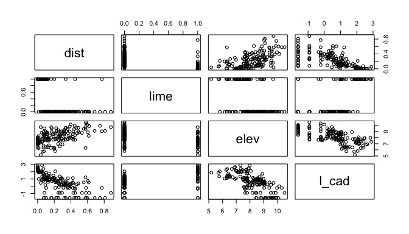

```r
pairs(df_meuse)
```

Indeed, we note linear relationships between `l_cad` on the one hand and `elev` as well as `dist` on the otherhand. Further, when `lime` is equal to 1, i.e., there is lime present in the soil, the cadmium measurements are higher.

### Linear Model

As a baseline, we start with a linear model again.

```r
fit_lm <- lm(l_cad ~ ., data = df_meuse)
summary(fit_lm)
```

```
##
## Call:
## lm(formula = l_cad ~ ., data = df_meuse)
##
## Residuals:
##     Min      1Q  Median      3Q     Max
## -2.5731 -0.4291  0.1752  0.5395  1.4191
##
## Coefficients:
##             Estimate Std. Error t value Pr(>|t|)
## (Intercept)  4.75085    0.56767   8.369 3.63e-14 ***
## dist        -2.04497    0.39846  -5.132 8.69e-07 ***
## lime         0.57632    0.16454   3.503 0.000606 ***
## elev        -0.47304    0.07087  -6.675 4.42e-10 ***
## ---
## Signif. codes:  0 '***' 0.001 '**' 0.01 '*' 0.05 '.' 0.1 ' ' 1
##
## Residual standard error: 0.7685 on 151 degrees of freedom
## Multiple R-squared:  0.6141, Adjusted R-squared:  0.6064
## F-statistic: 80.09 on 3 and 151 DF,  p-value: < 2.2e-16
```

The residual analysis shows:

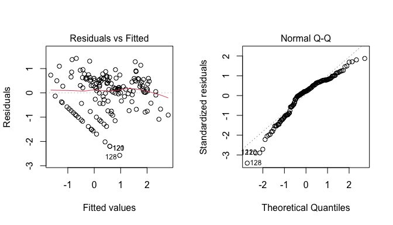

```r
oldpar <- par(mfrow = c(1, 2))
plot(fit_lm, which = 1:2)
```

```r
par(oldpar)
```

The spatial distribution of the residuals is the following:

[interactive chart not shown]

One can observe that there is a spatial clustering of the residuals. This motivates us to use an SVC model.

### SVC Model

The call to estimate the SVC model is again quite similar to the `lm()` call from above. However, we specify further arguments for the MLE using the `control` argument. First, we are using an optimization over the profiled likelihood (`profileLik = TRUE`) and second, we apply parameter scaling (`parscale = TRUE`) in the numeric optimization. Please check the help file `help("SVC_mle_control")` for more details.

```r
fit_svc <- SVC_mle(l_cad ~ ., data = df_meuse, locs = locs,
                   control = SVC_mle_control(
                     profileLik = TRUE,
                     parscale = TRUE
                   ))
summary(fit_svc)
```

```
##
## Call:
## SVC_mle.formula(formula = l_cad ~ ., data = df_meuse, locs = locs,
##     control = SVC_mle_control(profileLik = TRUE, parscale = TRUE))
##
## Fitting a GP-based SVC model with 4 fixed effect(s) and 4 SVC(s)
## using 155 observations at 155 different locations / coordinates.
##
## Residuals:
##     Min.   1st Qu.    Median   3rd Qu.      Max.
## -1.78853  -0.23591   0.01771   0.32363   0.92400
##
## Residual standard error: 0.4763
## Multiple R-squared: 0.8488, BIC: 365.9
##
##
## Coefficients of fixed effect(s):
##             Estimate Std. Error Z value Pr(>|Z|)
## (Intercept)  5.65232    0.59345   9.525  < 2e-16 ***
## dist        -2.31434    0.65744  -3.520 0.000431 ***
## lime         0.57317    0.19252   2.977 0.002910 **
## elev        -0.57116    0.06972  -8.193 2.55e-16 ***
## ---
## Signif. codes:  0 '***' 0.001 '**' 0.01 '*' 0.05 '.' 0.1 ' ' 1
##
##
## Covariance parameters of the SVC(s):
##                    Estimate Std. Error W value Pr(>W)
## (Intercept).range 5.833e+02         NA      NA     NA
## (Intercept).var   1.624e-01         NA      NA     NA
## dist.range        2.756e+02         NA      NA     NA
## dist.var          1.295e+00         NA      NA     NA
## lime.range        4.850e+02         NA      NA     NA
## lime.var          7.229e-02         NA      NA     NA
## elev.range        5.104e+03         NA      NA     NA
## elev.var          0.000e+00         NA      NA     NA
## nugget.var        3.181e-01         NA      NA     NA
##
## The covariance parameters were estimated using
## exponential covariance functions.
## No covariance tapering applied.
##
##
## MLE:
## The MLE terminated after 100 function evaluations with convergence code 0
## (0 meaning that the optimization was succesful).
## The final profile log likelihood value is -165.3.
```

The obtained mean coefficient values of the linear and SVC model are quite similar, but this doe not come as a surprise.

```r
kable(t(data.frame(
  cbind(`linear` = coef(fit_lm), `SVC`= coef(fit_svc))
)))
```

|  | (Intercept) | dist | lime | elev |
| --- | --- | --- | --- | --- |
| linear | 4.750845 | -2.044973 | 0.5763247 | -0.4730394 |
| SVC | 5.652316 | -2.314339 | 0.5731665 | -0.5711638 |

### Predictions

Additionaly to the `meuse` data the `sp` package also contains another data set called `meuse.grid` that contains a 40 by 40 meter spaced grid of the entire study area along the Meuse river. We can use the locations to predict the SVCs. However, the covariates `elev` and `lime` are missing. Therefore, we cannot predict the response. Again, the fitted SVC values are only the deviations from the mean. We observe that the SVC for `elev` is in fact constant.

```r
# study area
data("meuse.grid")

# prediction
df_svc_pred <- predict(fit_svc, newlocs = as.matrix(meuse.grid[, c("x", "y")]))
# outcome
head(df_svc_pred)
```

```
##       SVC_1      SVC_2      SVC_3 SVC_4  loc_1  loc_2
## 1 0.2004922 0.09882029 0.04280647     0 181180 333740
## 2 0.2169662 0.11452429 0.04797774     0 181140 333700
## 3 0.2132619 0.11474298 0.04543971     0 181180 333700
## 4 0.2081517 0.11375315 0.04257064     0 181220 333700
## 5 0.2340236 0.13166165 0.05360972     0 181100 333660
## 6 0.2310287 0.13362685 0.05089961     0 181140 333660
```

```r
# transformation to a spatial points data frame
colnames(df_svc_pred)[1:4] <- c("Intercept", "dist", "lime", "elev")

kable(head(df_svc_pred))
```

| Intercept | dist | lime | elev | loc_1 | loc_2 |
| --- | --- | --- | --- | --- | --- |
| 0.2004922 | 0.0988203 | 0.0428065 | 0 | 181180 | 333740 |
| 0.2169662 | 0.1145243 | 0.0479777 | 0 | 181140 | 333700 |
| 0.2132619 | 0.1147430 | 0.0454397 | 0 | 181180 | 333700 |
| 0.2081517 | 0.1137531 | 0.0425706 | 0 | 181220 | 333700 |
| 0.2340236 | 0.1316616 | 0.0536097 | 0 | 181100 | 333660 |
| 0.2310287 | 0.1336269 | 0.0508996 | 0 | 181140 | 333660 |

Here are the predicted SVCs for the entire study area, where we added the estimated mean to the deviations:

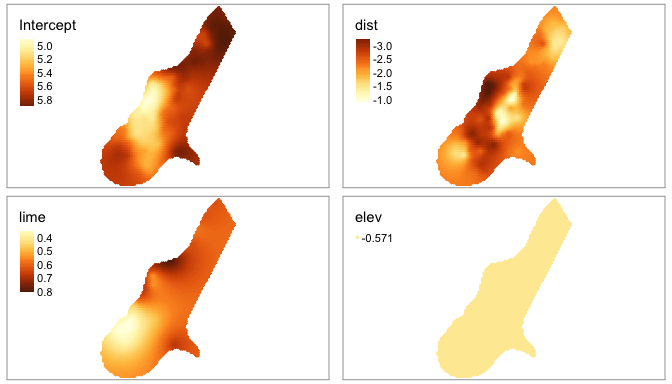

We see spatial structures in the first three coefficients, and the last one for covariate `elev` is constant. Our method is capable to estimate constant coefficients within the MLE. Further, there exist selection methods to not only select the varying coefficients, but to also select the mean value, i.e., the fixed effect.

## Conclusion

I hope that this example was easy to follow and showed the possibilities of how to model SVCs. I will continue my work on `varycoef` to add new and helpful features. On Twitter, I (@JakobDambon) will use #varycoef to announce updates. If there is a key feature missing or you have questions, please contact me by mailing to jakob.dambon (at) math.uzh.ch.

*Kind regards,*

*Jakob Dambon*

## References

Dambon, J. A., Sigrist, F., Furrer, R. (2021) **Maximum likelihood estimation of spatially varying coefficient models for large data with an application to real estate price prediction**, Spatial Statistics, 41 (100470). [doi:10.1016/j.spasta.2020.100470](https://doi.org/10.1016/j.spasta.2020.100470)

Dambon, J.A., Fahrländer, S.S., Karlen, S. et al. (2022) **Examining the vintage effect in hedonic pricing using spatially varying coefficients models: a case study of single-family houses in the Canton of Zurich**, Swiss Journal Economics Statistics 158(2). [doi:10.1186/s41937-021-00080-2](https://doi.org/10.1186/s41937-021-00080-2)

Dambon et al. (2022b)